# Machine learning for signal processing (Homework 2)

#### IU user name: vgopala

#### Full name: Vijaya Krishna Gopalakrishnan Partha

### Importing all required libraries

```python
import os
import cv2
import numpy as np
import pandas as pd
from scipy import io
import librosa as lb
import seaborn as sns
import matplotlib.pyplot as plt
```

### Loading data

```python
src_dir = 'M:/Spring 2020/MLSP/HW2/data'
x, sr = lb.load(os.path.join(src_dir, 'x.wav'), sr = None)
```

### Creating Direct Fourier Transform matrix

```python
def dft_matrix(m_size):
    dft_matrix = np.array([[np.exp(-1j * (2 * np.pi * f * n / m_size)) for f in range(0, m_size)] for n in range(0, m_size)])
    return dft_matrix
```

Taking N as 1600

```python
N = 1600
```

```python
dft_mat = dft_matrix(N)
print('The shape of the resulting DFT matrix is: ' + str(dft_mat.shape))
```

```
The shape of the resulting DFT matrix is: (1600, 1600)
```

### Preparing data matrix by applying hann window

```python
def hann_window(raw_data, m_size):
    hann_w = np.hanning(m_size)
    new_data = []

    counter = 0

    while counter + m_size <= raw_data.shape[0]:
        data_window = np.multiply(raw_data[counter:counter+m_size], hann_w)
        new_data.append(data_window)

        counter += int(m_size/2)

    new_data_matrix = np.array(new_data).T

    return new_data_matrix
```

```python
X_data = hann_window(x, N)
print('The shape of the original frequency spectrum is: ' + str(x.reshape(-1,1).shape))
print('The shape of new data matrix after applying hanning window: ' + str(X_data.shape))
```

```
The shape of the original frequency spectrum is: (63488, 1)
The shape of new data matrix after applying hanning window: (1600, 78)
```

### Plotting the new data matrix

Taking a dot product of the DFT matrix and the transformed data matrix

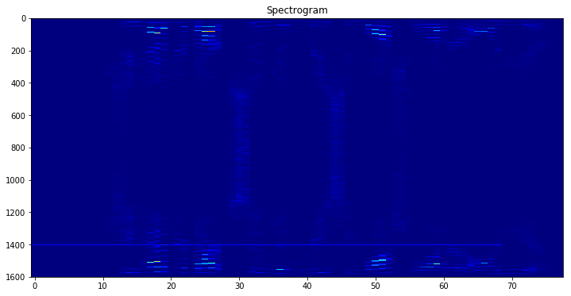

```python
spectrogram_1 = np.dot(dft_mat, X_data)
spectrogram_1_abs = np.abs(spectrogram_1)

plt.figure(figsize= (12,6))
plt.title("Spectrogram")
plt.imshow(spectrogram_1_abs, cmap='jet', aspect='auto')
plt.show()
```

From the above plotted spectrogram, we can see the beep sound as a horizontal line in the spectrogram.

Removing the noise manually by creating a window

```python
noise_window = np.mean(spectrogram_1_abs[:,spectrogram_1_abs.shape[1] - 200:], axis = 1).reshape(-1,1)
cleaned_spec = spectrogram_1_abs - noise_window
cleaned_spec[cleaned_spec<0] = 0
```

```python
original_magnitude = np.multiply(spectrogram_1, 1 / spectrogram_1_abs)
clean_spectrogram = np.multiply(original_magnitude, cleaned_spec)
```

```python
def idft_matrix(m_size):

    dft_matrix = np.array([[np.exp(1j * (2 * np.pi * f * n /m_size)) for f in range(0,m_size)] for n in range(0,m_size)])
    idft_matrix = dft_matrix/m_size

    return idft_matrix

idft_mat = idft_matrix(1600)

print('The shape of the idft matrix is: ' + str(idft_mat.shape))
```

```
The shape of the idft matrix is: (1600, 1600)
```

```python
fstar_f = np.dot(idft_mat, dft_mat)
print('We can see that F*F is an identity matrix: ' + str(np.abs(np.round(fstar_f.real))))
```

```
We can see that F*F is an identity matrix: [[1. 0. 0. ... 0. 0. 0.]
 [0. 1. 0. ... 0. 0. 0.]
 [0. 0. 1. ... 0. 0. 0.]
 ...
 [0. 0. 0. ... 1. 0. 0.]
 [0. 0. 0. ... 0. 1. 0.]
 [0. 0. 0. ... 0. 0. 1.]]
```

Recovering the clean signal by taking a dot product of the idft matrix with the recovered version of the data matrix

```python
X_hat = np.dot(idft_mat, clean_spectrogram)
```

```python
def reversing_overlap(X, m_size):

    X_out = X[:(X.shape[0] - int(m_size/2)),0]
    for col in range(1,X.shape[1]):
        X_col = X[(X.shape[0] - int(m_size/2)):,col-1] + X[0:int(m_size/2),col]
        X_out = np.concatenate((X_out,X_col))

    X_out = X_out.reshape(-1)

    return X_out
```

Taking the real values of X hat and reversing the overlap

```python
recovered_time_signal = reversing_overlap(X_hat.real, 1600)
```

```python
lb.output.write_wav(os.path.join(src_dir, 'cleaned_output.wav'), recovered_time_signal, sr = 16000)
```

```python
from IPython.display import Audio
print('Below is the original audio file ')
Audio(x, rate = 16000)
```

```
Below is the original audio file
```

[interactive chart not shown]

```python
print('Below is the de-beeped audio file ')
Audio(recovered_time_signal, rate = 16000)
```

```
Below is the de-beeped audio file
```

[interactive chart not shown]

Hearing both the above audio file, we can observe most of the beep sound removed from the original audio file.

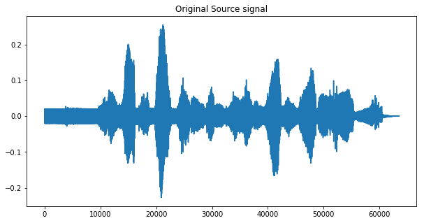

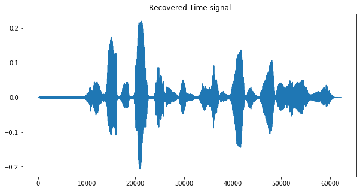

```python
#Ploting original signal
x_range = range(x.shape[0])
plt.figure(figsize= (10,5))
plt.title("Original Source signal")
plt.plot(x_range, x)
plt.show()

#Ploting recovered signal
x_range = range(recovered_time_signal.shape[0])
plt.figure(figsize= (10,5))
plt.title("Recovered Time signal")
plt.plot(x_range, recovered_time_signal)
plt.show()
```

In the original time signal plot, we can see that the plot is less spiky because of the constant beep sound. After removing the beep sound and plotting the recovered time signal, the spikes are more sharp along the axis.

## Problem 2

### Loading the data

```python
june = io.loadmat(os.path.join(src_dir, 'june'))['june']
december = io.loadmat(os.path.join(src_dir, 'december'))['december']
```

```python
print(june.shape)
print(december.shape)
```

```
(2700, 2)
(2700, 2)
```

### Creating disparity matrix

```python
disparity_matrix = december[:,0] - june[:,0]
disparity_matrix = disparity_matrix.reshape(-1,1)

print('The shape of disparity matrix is: ' + str(disparity_matrix.shape))
```

```
The shape of disparity matrix is: (2700, 1)
```

### Plotting the disparity matrix histogram

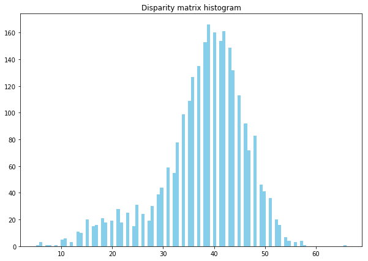

```python
plt.figure(figsize = (10,7))
plt.title('Disparity matrix histogram')
plt.hist(disparity_matrix, bins = 100, color = 'skyblue')
plt.show()
```

From the above histogram, we can see there are two clusters with varying means in the shape of two overlapping gaussian distributions.

```python
def k_Means_Clustering(data, number_clusters, max_iter, tolerance):

    #randomly initiating two cluster centroids
    clusters = np.random.uniform(low = int(min(data)), high = int(max(data)), size = number_clusters).reshape(-1,1)
    cluster_matrix = np.array([[0.0] * number_clusters] * data.shape[0])

    iter_count = 0
    while iter_count <= max_iter:

        for i in range(0, len(data)):
            if (np.abs(data[i] - clusters[0])) < (np.abs(data[i] - clusters[1])):
                cluster_matrix[i][0] = 1
                cluster_matrix[i][1] = 0
            else:
                cluster_matrix[i][1] = 1
                cluster_matrix[i][0] = 0

        cluster_previous = clusters

        cluster_centroids_dot = np.dot(data.T, cluster_matrix)
        total_sum = np.sum(cluster_matrix, axis = 0)

        clusters = (cluster_centroids_dot/total_sum).reshape(-1)
        print(clusters)

        iter_count += 1

        #Early stopping
        if np.abs(clusters[0] - cluster_previous[0]) < tolerance and np.abs(clusters[1] - cluster_previous[1]) < tolerance:
            break

    #Below method to create dataframe for visualisation purpose referenced from
    # https://tomaugspurger.github.io/modern-6-visualization.html
    #Start
    result_df = pd.DataFrame(data)

    result_df.columns = ['Disparity Data']
    result_df['Cluster'] = np.argmax(cluster_matrix, axis = 1)
    #End

    return clusters, result_df
```

```python
clusters, dataframe = k_Means_Clustering(disparity_matrix, number_clusters = 2, max_iter = 1000, tolerance = 0.0001)
```

```
[17.14720812 39.49620455]
[20.71847507 40.34421365]
[22.44339623 40.73857645]
[23.48861284 40.9977447 ]
[24.35873606 41.226642  ]
[24.35873606 41.226642  ]
```

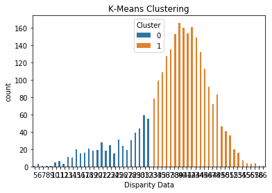

```python
sns.countplot(dataframe['Disparity Data'], hue = dataframe['Cluster']).set_title("K-Means Clustering")
plt.show()
```

```python
print('The cluster centroids are ' + str(round(clusters[0], 3)) + ' and ' + str(round(clusters[1], 3)))
```

[output not shown]